# Problem Statement

Pada tahun 2001, 2002, dan 2005, Taiwan merupakan salah satu negara yang mengalami debt crisis (Chang, 2022). Salah satu faktor yang menyebabkan terjadinya krisis tersebut seperti tidak adanya pengawasan dari pihak bank terkait status pengajuan kartu kredit nasabah dan reporting system yang tidak teratur. Pengecekan histori transaksi nasabah harus dilakukan dalam menentukan apakah pengajuan kartu kredit nasabah bisa diterima atau tidak, sehingga potensi untuk mendapatkan nasabah yang bisa mengakibatkan gagal bayar bisa menjadi berkurang.

# Goals

Menurunkan jumlah nasabah yang berpotensi mengalami gagal bayar

# Objective

Melakukan proses EDA untuk memahami dataset yang diberikan Melakukan proses data preparation seperti data cleansing untuk menghasilkan data training dan data test Menentukan model yang tepat untuk mengidentifikasi nasabah yang berpotensi untuk terkena gagal bayar terhadap data training yang sudah dihasilkan sebelumnya Melakukan evaluasi model yang sudah ditentukan terhadap data set yang sudah dihasilkan sebelumnya

```python
# Importing all libraries
import pandas as pd
import numpy as np
import matplotlib.pyplot as plt
import seaborn as sns
%matplotlib inline

import warnings
warnings.filterwarnings('ignore')
```

```python
from sklearn.preprocessing import StandardScaler
from sklearn.model_selection import train_test_split
from sklearn.linear_model import LogisticRegression
from sklearn.model_selection import GridSearchCV

from sklearn.metrics import accuracy_score, recall_score, precision_score, f1_score, roc_auc_score, confusion_matrix, roc_curve, auc

from sklearn.svm import SVC
```

```python
df = pd.read_csv('train_20D8GL3.csv')
df
```

|  | ID | LIMIT_BAL | SEX | EDUCATION | MARRIAGE | AGE | PAY_0 | PAY_2 | PAY_3 | PAY_4 | ... | BILL_AMT4 | BILL_AMT5 | BILL_AMT6 | PAY_AMT1 | PAY_AMT2 | PAY_AMT3 | PAY_AMT4 | PAY_AMT5 | PAY_AMT6 | default_payment_next_month |
| --- | --- | --- | --- | --- | --- | --- | --- | --- | --- | --- | --- | --- | --- | --- | --- | --- | --- | --- | --- | --- | --- |
| 0 | 25150 | 360000 | 2 | 2 | 2 | 25 | -1 | -1 | -1 | -1 | ... | 3435 | 8870 | 2020 | 12590 | 3479 | 3446 | 8870 | 2020 | 27043 | 0 |
| 1 | 13470 | 240000 | 2 | 1 | 2 | 46 | 2 | 2 | -2 | -1 | ... | 2240 | 1681 | 2267 | 0 | 0 | 2240 | 0 | 2267 | 3074 | 0 |
| 2 | 3092 | 320000 | 2 | 2 | 1 | 41 | 0 | 0 | 0 | 0 | ... | 35409 | 35036 | 35939 | 5000 | 2000 | 2000 | 3000 | 3000 | 1500 | 0 |
| 3 | 13973 | 50000 | 2 | 2 | 2 | 24 | -1 | -1 | -2 | -2 | ... | 0 | 0 | 0 | 0 | 0 | 0 | 0 | 0 | 0 | 1 |
| 4 | 10567 | 80000 | 1 | 3 | 1 | 52 | -1 | 0 | 0 | 0 | ... | 20561 | 21261 | 21457 | 1500 | 1500 | 1500 | 1028 | 876 | 1449 | 0 |
| ... | ... | ... | ... | ... | ... | ... | ... | ... | ... | ... | ... | ... | ... | ... | ... | ... | ... | ... | ... | ... | ... |
| 20995 | 6283 | 50000 | 2 | 2 | 2 | 31 | 1 | -2 | -2 | -2 | ... | 0 | 0 | 0 | 0 | 0 | 0 | 0 | 0 | 0 | 0 |
| 20996 | 25589 | 80000 | 2 | 2 | 1 | 37 | 0 | 0 | 0 | 0 | ... | 45458 | 48679 | 49895 | 5000 | 3000 | 2000 | 4000 | 2000 | 2000 | 0 |
| 20997 | 4378 | 100000 | 1 | 1 | 1 | 52 | 1 | 2 | 2 | 2 | ... | 23440 | 28843 | 31353 | 0 | 3600 | 0 | 6000 | 3000 | 0 | 1 |
| 20998 | 8604 | 90000 | 2 | 2 | 1 | 47 | 0 | 0 | 0 | 0 | ... | 28747 | 29177 | 29452 | 2000 | 2000 | 2000 | 2000 | 2000 | 2000 | 0 |
| 20999 | 18049 | 90000 | 1 | 3 | 1 | 44 | 1 | -2 | -2 | -2 | ... | 0 | 0 | 0 | 0 | 0 | 0 | 0 | 0 | 0 | 1 |

21000 rows × 25 columns

```python
df.info()
```

```
<class 'pandas.core.frame.DataFrame'>
RangeIndex: 21000 entries, 0 to 20999
Data columns (total 25 columns):
 #   Column                      Non-Null Count  Dtype
---  ------                      --------------  -----
 0   ID                          21000 non-null  int64
 1   LIMIT_BAL                   21000 non-null  int64
 2   SEX                         21000 non-null  int64
 3   EDUCATION                   21000 non-null  int64
 4   MARRIAGE                    21000 non-null  int64
 5   AGE                         21000 non-null  int64
 6   PAY_0                       21000 non-null  int64
 7   PAY_2                       21000 non-null  int64
 8   PAY_3                       21000 non-null  int64
 9   PAY_4                       21000 non-null  int64
```

[output cut: 17 more lines]

**Apa yang kita ketahui tentang kumpulan data**:

**Kami memiliki catatan 21000 pelanggan. Di bawah ini adalah deskripsi dari semua fitur yang kami miliki.**

**ID**: ID dari setiap klien

**LIMIT_BAL**: Jumlah kredit yang diberikan dalam dolar (termasuk kredit individu dan keluarga/tambahan)

**JENIS KELAMIN**: Jenis Kelamin (1 = laki-laki, 2 = perempuan)

**PENDIDIKAN**: (1 = lulusan sekolah, 2 = universitas, 3 = SMA, 0,4,5,6 = lainnya)

**PERNIKAHAN**: Status pernikahan (0 = lainnya, 1 = menikah, 2 = lajang, 3 = lainnya)

**USIA** : Umur dalam tahun

**Skala untuk PAY_0 hingga PAY_6 :**

-2 = Tanpa konsumsi,

-1 = dibayar lunas,

0 = penggunaan kredit bergulir (dibayar minimum saja),

1 = penundaan pembayaran selama satu bulan, 2 = penundaan pembayaran selama dua bulan,

8 = penundaan pembayaran selama delapan bulan,

9 = penundaan pembayaran selama sembilan bulan ke atas

BILL_AMT1: Jumlah laporan tagihan pada bulan September 2005

BILL_AMT2: Jumlah tagihan pada bulan Agustus 2005

BILL_AMT3: Jumlah tagihan bulan Juli 2005

BILL_AMT4: Jumlah laporan tagihan pada bulan Juni 2005

BILL_AMT5: Jumlah laporan tagihan bulan Mei 2005

BILL_AMT6: Jumlah laporan tagihan pada bulan April 2005

PAY_AMT1: Jumlah pembayaran sebelumnya pada bulan September 2005

PAY_AMT2: Jumlah pembayaran sebelumnya pada bulan Agustus 2005

PAY_AMT3: Jumlah pembayaran sebelumnya pada bulan Juli 2005

PAY_AMT4: Jumlah pembayaran sebelumnya pada bulan Juni 2005

PAY_AMT5: Jumlah pembayaran sebelumnya pada bulan Mei 2005

PAY_AMT6: Jumlah pembayaran sebelumnya pada bulan April 2005

default.payment.next.month: Pembayaran default (1=ya, 0=tidak)

Dalam dataset kami, kami mendapatkan riwayat transaksi kartu kredit pelanggan selama 6 bulan terakhir, yang menjadi dasar kami harus memprediksi apakah pelanggan akan default atau tidak.

kami akan memeriksa apakah kami memiliki nilai yang hilang

```python
df.isnull().sum()
```

```
ID                            0
LIMIT_BAL                     0
SEX                           0
EDUCATION                     0
MARRIAGE                      0
AGE                           0
PAY_0                         0
PAY_2                         0
PAY_3                         0
PAY_4                         0
PAY_5                         0
PAY_6                         0
BILL_AMT1                     0
BILL_AMT2                     0
BILL_AMT3                     0
BILL_AMT4                     0
BILL_AMT5                     0
BILL_AMT6                     0
PAY_AMT1                      0
PAY_AMT2                      0
PAY_AMT3                      0
PAY_AMT4                      0
PAY_AMT5                      0
PAY_AMT6                      0
default_payment_next_month    0
dtype: int64
```

```python
df.describe()
```

|  | ID | LIMIT_BAL | SEX | EDUCATION | MARRIAGE | AGE | PAY_0 | PAY_2 | PAY_3 | PAY_4 | ... | BILL_AMT4 | BILL_AMT5 | BILL_AMT6 | PAY_AMT1 | PAY_AMT2 | PAY_AMT3 | PAY_AMT4 | PAY_AMT5 | PAY_AMT6 | default_payment_next_month |
| --- | --- | --- | --- | --- | --- | --- | --- | --- | --- | --- | --- | --- | --- | --- | --- | --- | --- | --- | --- | --- | --- |
| count | 21000.000000 | 21000.000000 | 21000.000000 | 21000.000000 | 21000.000000 | 21000.000000 | 21000.00000 | 21000.000000 | 21000.000000 | 21000.00000 | ... | 21000.000000 | 21000.000000 | 21000.000000 | 21000.000000 | 2.100000e+04 | 21000.000000 | 21000.000000 | 21000.000000 | 21000.000000 | 21000.000000 |
| mean | 14949.183667 | 167214.746667 | 1.607571 | 1.854190 | 1.551714 | 35.461619 | -0.01119 | -0.127238 | -0.164857 | -0.21819 | ... | 43387.372476 | 40398.551095 | 38931.194000 | 5686.349333 | 5.923003e+03 | 5202.325333 | 4793.172000 | 4797.012952 | 5211.736762 | 0.221190 |
| std | 8632.775153 | 128965.188482 | 0.488303 | 0.791628 | 0.521176 | 9.206628 | 1.12321 | 1.198957 | 1.198624 | 1.17221 | ... | 64081.073110 | 60396.811177 | 59196.499234 | 16868.075695 | 2.390953e+04 | 17006.416467 | 15467.403159 | 15270.031988 | 17698.795697 | 0.415058 |
| min | 1.000000 | 10000.000000 | 1.000000 | 0.000000 | 0.000000 | 21.000000 | -2.00000 | -2.000000 | -2.000000 | -2.00000 | ... | -170000.000000 | -81334.000000 | -209051.000000 | 0.000000 | 0.000000e+00 | 0.000000 | 0.000000 | 0.000000 | 0.000000 | 0.000000 |
| 25% | 7508.750000 | 50000.000000 | 1.000000 | 1.000000 | 1.000000 | 28.000000 | -1.00000 | -1.000000 | -1.000000 | -1.00000 | ... | 2332.000000 | 1759.000000 | 1242.750000 | 998.250000 | 8.360000e+02 | 390.000000 | 284.000000 | 241.000000 | 102.000000 | 0.000000 |
| 50% | 14939.500000 | 140000.000000 | 2.000000 | 2.000000 | 2.000000 | 34.000000 | 0.00000 | 0.000000 | 0.000000 | 0.00000 | ... | 19158.500000 | 18266.500000 | 17203.500000 | 2100.000000 | 2.011000e+03 | 1811.500000 | 1500.000000 | 1500.000000 | 1500.000000 | 0.000000 |
| 75% | 22386.750000 | 240000.000000 | 2.000000 | 2.000000 | 2.000000 | 41.000000 | 0.00000 | 0.000000 | 0.000000 | 0.00000 | ... | 55376.750000 | 50517.250000 | 49463.000000 | 5023.250000 | 5.000000e+03 | 4500.000000 | 4002.250000 | 4051.000000 | 4000.000000 | 0.000000 |
| max | 29998.000000 | 800000.000000 | 2.000000 | 6.000000 | 3.000000 | 75.000000 | 8.00000 | 8.000000 | 8.000000 | 8.00000 | ... | 706864.000000 | 587067.000000 | 699944.000000 | 873552.000000 | 1.684259e+06 | 889043.000000 | 621000.000000 | 417990.000000 | 528666.000000 | 1.000000 |

8 rows × 25 columns

```python
#mengganti nama kolom agar lebih nyaman / mudah
df['IsDefaulter'] =df ['default_payment_next_month']
df.drop('default_payment_next_month',axis = 1)
```

|  | ID | LIMIT_BAL | SEX | EDUCATION | MARRIAGE | AGE | PAY_0 | PAY_2 | PAY_3 | PAY_4 | ... | BILL_AMT4 | BILL_AMT5 | BILL_AMT6 | PAY_AMT1 | PAY_AMT2 | PAY_AMT3 | PAY_AMT4 | PAY_AMT5 | PAY_AMT6 | IsDefaulter |
| --- | --- | --- | --- | --- | --- | --- | --- | --- | --- | --- | --- | --- | --- | --- | --- | --- | --- | --- | --- | --- | --- |
| 0 | 25150 | 360000 | 2 | 2 | 2 | 25 | -1 | -1 | -1 | -1 | ... | 3435 | 8870 | 2020 | 12590 | 3479 | 3446 | 8870 | 2020 | 27043 | 0 |
| 1 | 13470 | 240000 | 2 | 1 | 2 | 46 | 2 | 2 | -2 | -1 | ... | 2240 | 1681 | 2267 | 0 | 0 | 2240 | 0 | 2267 | 3074 | 0 |
| 2 | 3092 | 320000 | 2 | 2 | 1 | 41 | 0 | 0 | 0 | 0 | ... | 35409 | 35036 | 35939 | 5000 | 2000 | 2000 | 3000 | 3000 | 1500 | 0 |
| 3 | 13973 | 50000 | 2 | 2 | 2 | 24 | -1 | -1 | -2 | -2 | ... | 0 | 0 | 0 | 0 | 0 | 0 | 0 | 0 | 0 | 1 |
| 4 | 10567 | 80000 | 1 | 3 | 1 | 52 | -1 | 0 | 0 | 0 | ... | 20561 | 21261 | 21457 | 1500 | 1500 | 1500 | 1028 | 876 | 1449 | 0 |
| ... | ... | ... | ... | ... | ... | ... | ... | ... | ... | ... | ... | ... | ... | ... | ... | ... | ... | ... | ... | ... | ... |
| 20995 | 6283 | 50000 | 2 | 2 | 2 | 31 | 1 | -2 | -2 | -2 | ... | 0 | 0 | 0 | 0 | 0 | 0 | 0 | 0 | 0 | 0 |
| 20996 | 25589 | 80000 | 2 | 2 | 1 | 37 | 0 | 0 | 0 | 0 | ... | 45458 | 48679 | 49895 | 5000 | 3000 | 2000 | 4000 | 2000 | 2000 | 0 |
| 20997 | 4378 | 100000 | 1 | 1 | 1 | 52 | 1 | 2 | 2 | 2 | ... | 23440 | 28843 | 31353 | 0 | 3600 | 0 | 6000 | 3000 | 0 | 1 |
| 20998 | 8604 | 90000 | 2 | 2 | 1 | 47 | 0 | 0 | 0 | 0 | ... | 28747 | 29177 | 29452 | 2000 | 2000 | 2000 | 2000 | 2000 | 2000 | 0 |
| 20999 | 18049 | 90000 | 1 | 3 | 1 | 44 | 1 | -2 | -2 | -2 | ... | 0 | 0 | 0 | 0 | 0 | 0 | 0 | 0 | 0 | 1 |

21000 rows × 25 columns

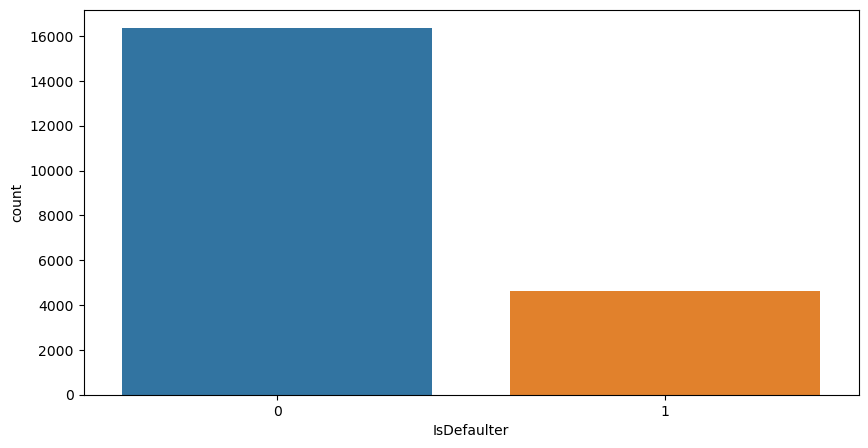

```python
plt.figure(figsize=(10,5))
sns.countplot(x = 'IsDefaulter', data = df)
```

```python
df['IsDefaulter'].value_counts()
```

```
0    16355
1     4645
Name: IsDefaulter, dtype: int64
```

Seperti yang dapat kita lihat dari grafik di atas bahwa kedua kelas tidak proporsional dan kami memiliki kumpulan data yang tidak seimbang.

# Categorical Features

Kami memiliki beberapa fitur kategorikal dalam kumpulan data kami. Mari kita periksa bagaimana mereka terkait dengan kelas target kita.

# SEX

1 - Male 2 - Female

```python
df['SEX'].value_counts()
```

```
2    12759
1     8241
Name: SEX, dtype: int64
```

# Education

1 = Graduate School

2 = University

3 = High School

4 = Others

```python
df['EDUCATION'].value_counts()
```

```
2    9789
1    7415
3    3467
5     200
4      85
6      34
0      10
Name: EDUCATION, dtype: int64
```

Seperti yang dapat kita lihat dalam kumpulan data, kita memiliki nilai seperti 5,6,0 juga yang tidak memiliki deskripsi sehingga kita dapat menjumlahkannya dalam 4, yaitu Lainnya.

```python
fil = (df['EDUCATION'] == 5) | (df['EDUCATION'] == 6) | (df['EDUCATION'] == 0)
df.loc[fil, 'EDUCATION'] = 4
df['EDUCATION'].value_counts()
```

```
2    9789
1    7415
3    3467
4     329
Name: EDUCATION, dtype: int64
```

# Marriage

1 = Married, 2 = Single, 3 = Others

```python
df['MARRIAGE'].value_counts()
```

```
2    11184
1     9561
3      219
0       36
Name: MARRIAGE, dtype: int64
```

Kami memiliki beberapa nilai untuk 0, yang tidak ditentukan . Jadi saya menambahkannya dalam kategori Lainnya.

```python
fil = df['MARRIAGE'] == 0
df.loc[fil, 'MARRIAGE'] = 3
df['MARRIAGE'].value_counts()
```

```
2    11184
1     9561
3      255
Name: MARRIAGE, dtype: int64
```

# Plotting our categorical features

```python
categorical_features = ['SEX', 'EDUCATION', 'MARRIAGE']
```

```python
df_cat = df[categorical_features]
df_cat['Defaulter'] = df['IsDefaulter']
```

```python
df_cat.replace({'SEX': {1 : 'MALE', 2 : 'FEMALE'}, 'EDUCATION' : {1 : 'graduate school', 2 : 'university', 3 : 'high school', 4 : 'others'}, 'MARRIAGE' : {1 : 'married', 2 : 'single', 3 : 'others'}}, inplace = True)
```

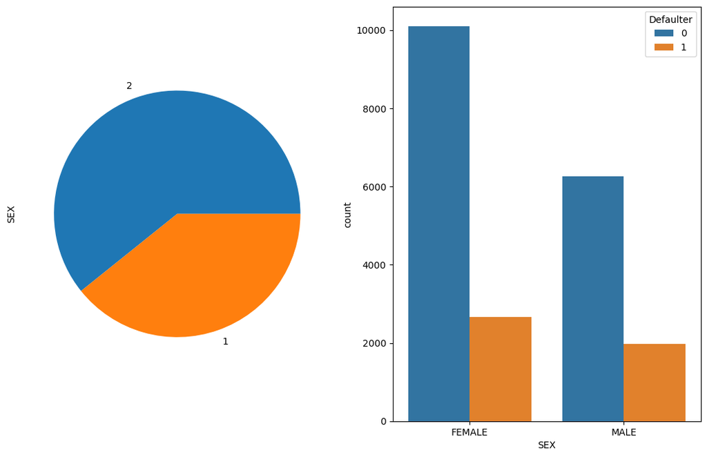

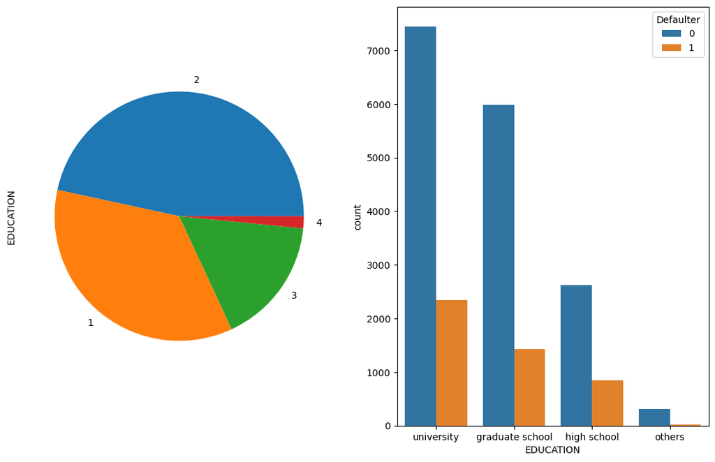

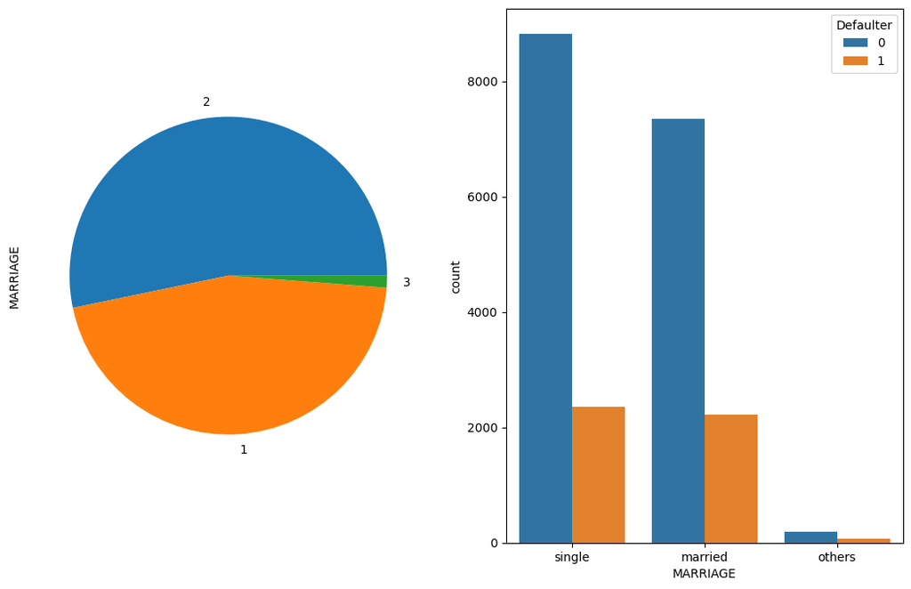

```python
for col in categorical_features:
  plt.figure(figsize=(10,5))
  fig, axes = plt.subplots(ncols=2,figsize=(13,8))
  df[col].value_counts().plot(kind="pie",ax = axes[0],subplots=True)
  sns.countplot(x = col, hue = 'Defaulter', data = df_cat)
```

Di bawah ini adalah beberapa pengamatan untuk fitur kategorikal:

Ada lebih banyak pemegang kartu kredit wanita, default memiliki proporsi perempuan yang tinggi.

Jumlah orang yang default memiliki proporsi orang berpendidikan lebih tinggi (sekolah pascasarjana dan universitas)

Jumlah orang yang default memiliki proporsi Single yang lebih tinggi.

# Limit Balance

```python
df['LIMIT_BAL'].max()
```

```
800000
```

```python
df['LIMIT_BAL'].min()
```

```
10000
```

```python
df['LIMIT_BAL'].describe()
```

```
count     21000.000000
mean     167214.746667
std      128965.188482
min       10000.000000
25%       50000.000000
50%      140000.000000
75%      240000.000000
max      800000.000000
Name: LIMIT_BAL, dtype: float64
```

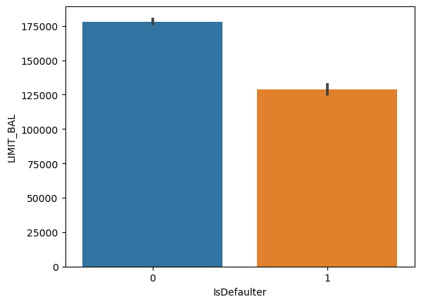

```python
sns.barplot(x='IsDefaulter', y='LIMIT_BAL', data=df)
```

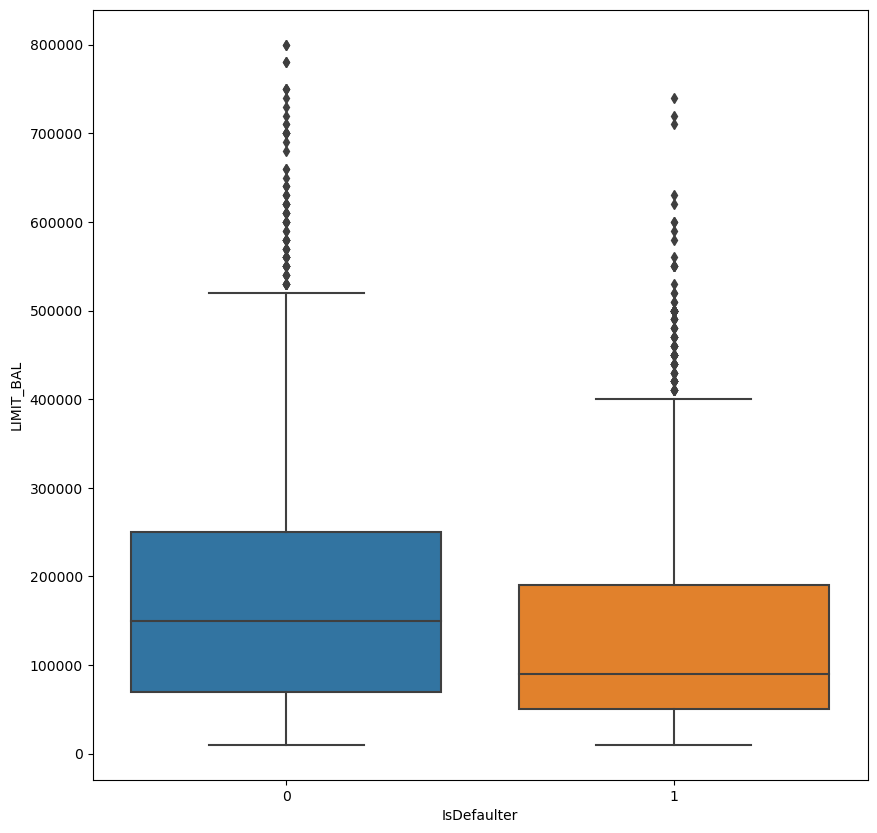

```python
plt.figure(figsize=(10,10))
ax = sns.boxplot(x="IsDefaulter", y="LIMIT_BAL", data=df)
```

```python
#Merubah Nama kolom agar lebih mudah dimenegerti
df.rename(columns={'PAY_0':'PAY_SEPT','PAY_2':'PAY_AUG','PAY_3':'PAY_JUL','PAY_4':'PAY_JUN','PAY_5':'PAY_MAY','PAY_6':'PAY_APR'},inplace=True)
df.rename(columns={'BILL_AMT1':'BILL_AMT_SEPT','BILL_AMT2':'BILL_AMT_AUG','BILL_AMT3':'BILL_AMT_JUL','BILL_AMT4':'BILL_AMT_JUN','BILL_AMT5':'BILL_AMT_MAY','BILL_AMT6':'BILL_AMT_APR'}, inplace = True)
df.rename(columns={'PAY_AMT1':'PAY_AMT_SEPT','PAY_AMT2':'PAY_AMT_AUG','PAY_AMT3':'PAY_AMT_JUL','PAY_AMT4':'PAY_AMT_JUN','PAY_AMT5':'PAY_AMT_MAY','PAY_AMT6':'PAY_AMT_APR'},inplace=True)
```

```python
df.head()
```

|  | ID | LIMIT_BAL | SEX | EDUCATION | MARRIAGE | AGE | PAY_SEPT | PAY_AUG | PAY_JUL | PAY_JUN | ... | BILL_AMT_MAY | BILL_AMT_APR | PAY_AMT_SEPT | PAY_AMT_AUG | PAY_AMT_JUL | PAY_AMT_JUN | PAY_AMT_MAY | PAY_AMT_APR | default_payment_next_month | IsDefaulter |
| --- | --- | --- | --- | --- | --- | --- | --- | --- | --- | --- | --- | --- | --- | --- | --- | --- | --- | --- | --- | --- | --- |
| 0 | 25150 | 360000 | 2 | 2 | 2 | 25 | -1 | -1 | -1 | -1 | ... | 8870 | 2020 | 12590 | 3479 | 3446 | 8870 | 2020 | 27043 | 0 | 0 |
| 1 | 13470 | 240000 | 2 | 1 | 2 | 46 | 2 | 2 | -2 | -1 | ... | 1681 | 2267 | 0 | 0 | 2240 | 0 | 2267 | 3074 | 0 | 0 |
| 2 | 3092 | 320000 | 2 | 2 | 1 | 41 | 0 | 0 | 0 | 0 | ... | 35036 | 35939 | 5000 | 2000 | 2000 | 3000 | 3000 | 1500 | 0 | 0 |
| 3 | 13973 | 50000 | 2 | 2 | 2 | 24 | -1 | -1 | -2 | -2 | ... | 0 | 0 | 0 | 0 | 0 | 0 | 0 | 0 | 1 | 1 |
| 4 | 10567 | 80000 | 1 | 3 | 1 | 52 | -1 | 0 | 0 | 0 | ... | 21261 | 21457 | 1500 | 1500 | 1500 | 1028 | 876 | 1449 | 0 | 0 |

5 rows × 26 columns

# Age

Merencanakan grafik jumlah usia semua orang dengan kartu kredit tanpa memandang jenis kelamin.

```python
df['AGE'].value_counts()
```

```
29    1088
27    1052
28     993
30     972
26     879
25     847
32     832
31     825
34     821
33     815
36     786
35     784
24     779
37     738
38     661
```

[output cut: 41 more lines]

```python
df['AGE']=df['AGE'].astype('int')
```

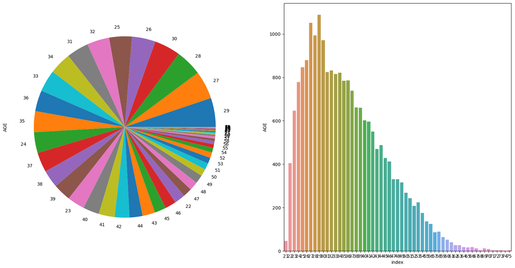

```python
fig, axes = plt.subplots(ncols=2,figsize=(20,10))
Day_df=df['AGE'].value_counts().reset_index()
df['AGE'].value_counts().plot(kind="pie",ax = axes[0],subplots=True)
sns.barplot(x='index',y='AGE',data=Day_df,ax = axes[1],orient='v')
```

```python
df.groupby('IsDefaulter')['AGE'].mean()
```

```
IsDefaulter
0    35.428921
1    35.576749
Name: AGE, dtype: float64
```

```python
df = df.astype('int')
```

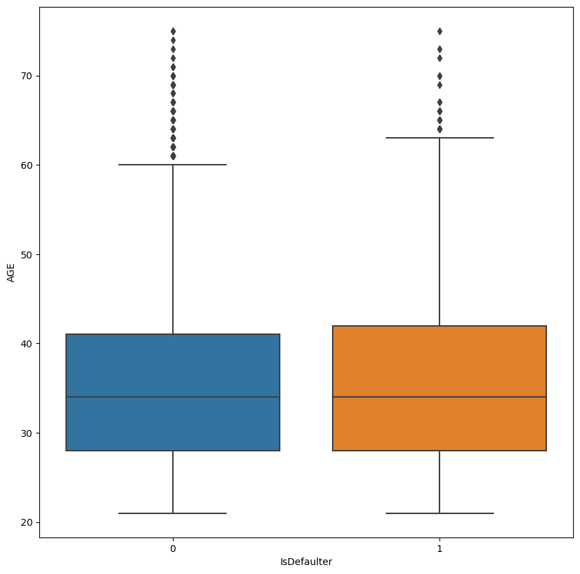

```python
plt.figure(figsize=(10,10))
ax = sns.boxplot(x='IsDefaulter', y='AGE', data=df)
```

# Bill Amount

```python
bill_amnt_df = df[['BILL_AMT_SEPT',	'BILL_AMT_AUG',	'BILL_AMT_JUL',	'BILL_AMT_JUN',	'BILL_AMT_MAY',	'BILL_AMT_APR']]
```

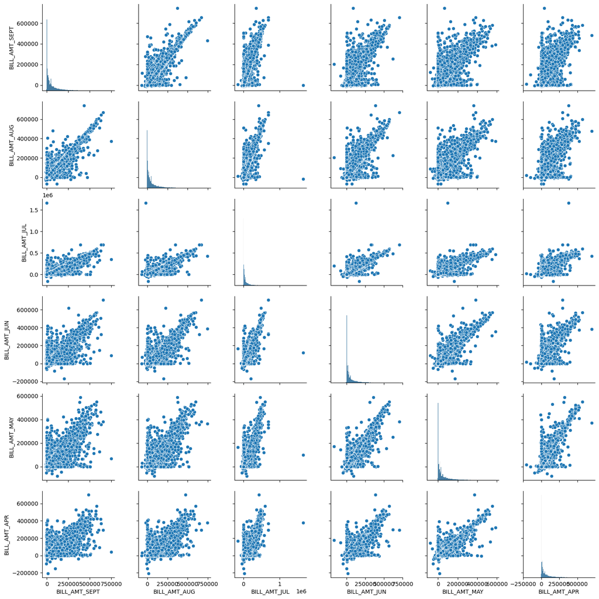

```python
sns.pairplot(data = bill_amnt_df)
```

**History Payment Status**

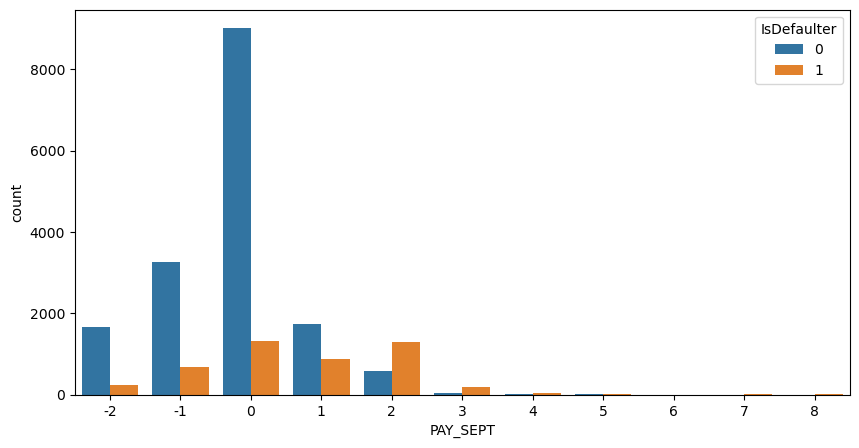

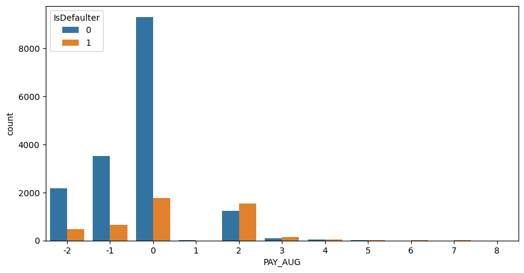

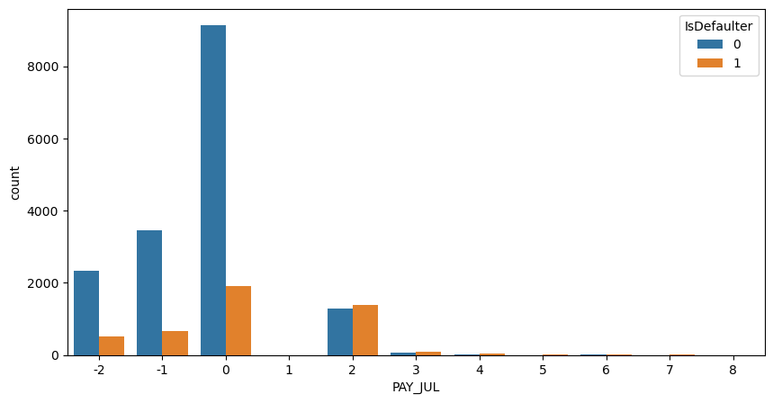

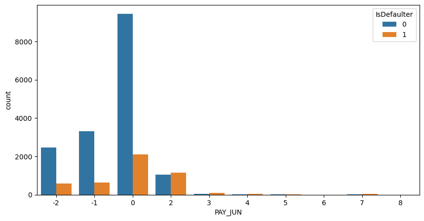

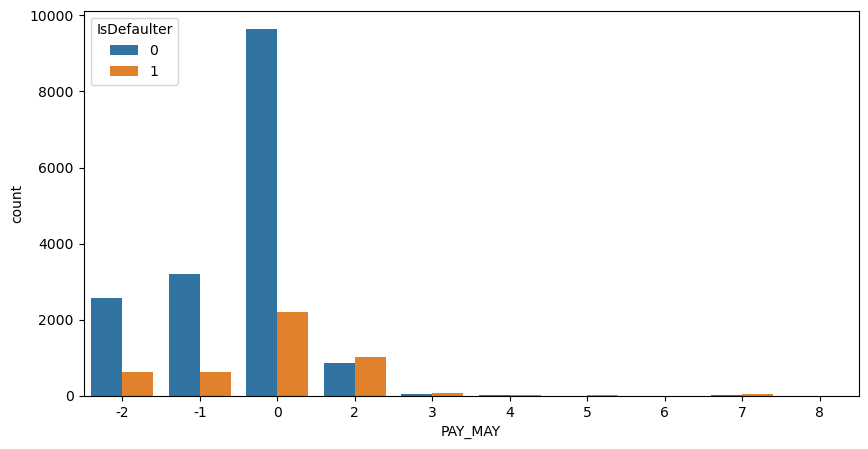

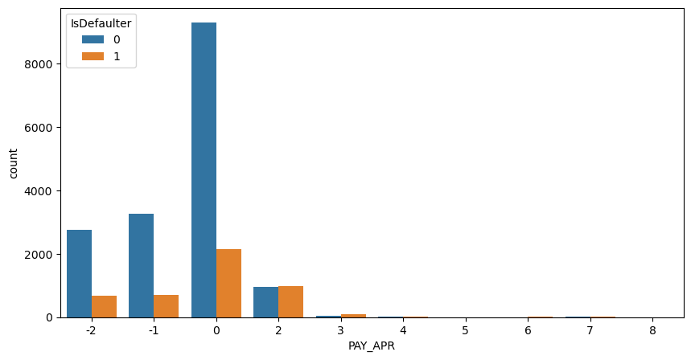

```python
pay_col = ['PAY_SEPT',	'PAY_AUG',	'PAY_JUL',	'PAY_JUN',	'PAY_MAY',	'PAY_APR']
for col in pay_col:
  plt.figure(figsize=(10,5))
  sns.countplot(x = col, hue = 'IsDefaulter', data = df)
```

# Paid Amount

```python
pay_amnt_df = df[['PAY_AMT_SEPT',	'PAY_AMT_AUG',	'PAY_AMT_JUL',	'PAY_AMT_JUN',	'PAY_AMT_MAY',	'PAY_AMT_APR', 'IsDefaulter']]
```

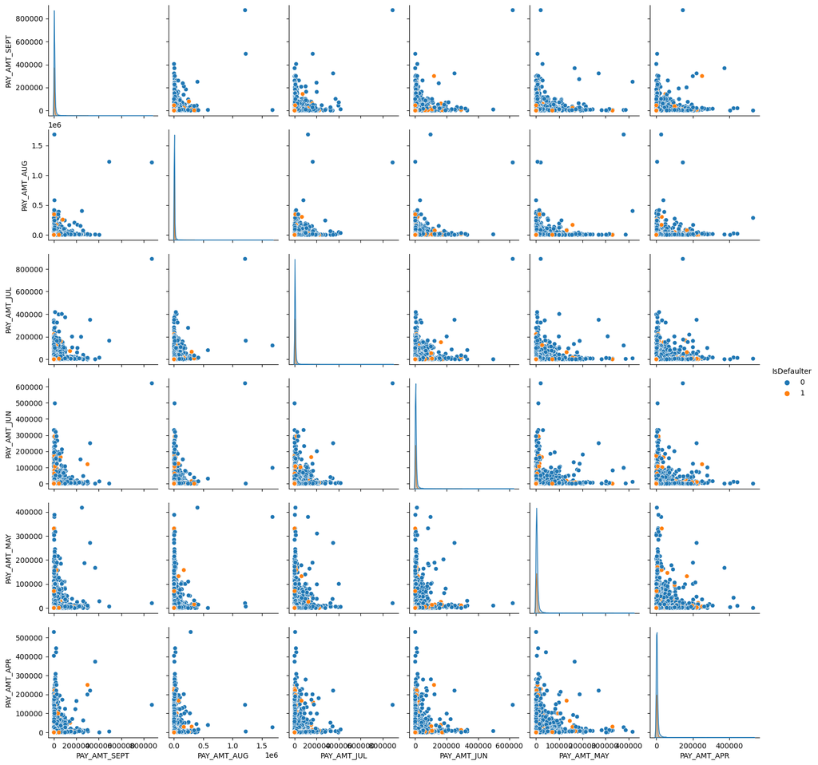

```python
sns.pairplot(data = pay_amnt_df, hue='IsDefaulter')
```

```python
df.shape
```

```
(21000, 26)
```

Seperti yang telah kita lihat sebelumnya bahwa kita memiliki kumpulan data yang tidak seimbang. Jadi untuk memulihkan Ketidakseimbangan kita menggunakan SMOTE(Synthetic Minority Oversampling Technique)

apa manfaat dari **SMOTE** ?

SMOTE digunakan untuk menangani masalah ketidakseimbangan kelas dalam machine learning. Masalah ketidakseimbangan kelas terjadi ketika kelas minoritas dalam dataset memiliki frekuensi yang jauh lebih rendah dibandingkan dengan kelas mayoritas. Contohnya, dalam dataset deteksi fraud di mana mayoritas transaksi adalah normal dan hanya beberapa transaksi yang merupakan fraud. Dalam kasus ini, model machine learning dapat menjadi cenderung untuk memprediksi mayoritas transaksi sebagai normal, dan tidak mampu mengidentifikasi dengan akurat transaksi yang merupakan fraud.

```python
#pip install imbalanced-learn
#klo misalnya erorr keemungkinan belum install
```

```python
from imblearn.over_sampling import SMOTE

smote = SMOTE()

# fit predictor and target variable
x_smote, y_smote = smote.fit_resample(df.iloc[:,0:-1], df['IsDefaulter'])

print('Original dataset shape', len(df))
print('Resampled dataset shape', len(y_smote))
```

```
Original dataset shape 21000
Resampled dataset shape 32710
```

```python
columns = list(df.columns)
```

```python
columns.pop()
```

```
'IsDefaulter'
```

```python
balance_df = pd.DataFrame(x_smote, columns=columns)
```

```python
balance_df['IsDefaulter'] = y_smote
```

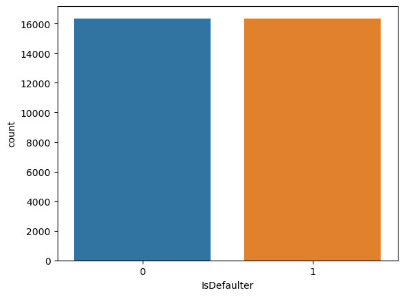

```python
sns.countplot('IsDefaulter', data = balance_df)
```

```python
balance_df[balance_df['IsDefaulter']==1]
```

|  | ID | LIMIT_BAL | SEX | EDUCATION | MARRIAGE | AGE | PAY_SEPT | PAY_AUG | PAY_JUL | PAY_JUN | ... | BILL_AMT_MAY | BILL_AMT_APR | PAY_AMT_SEPT | PAY_AMT_AUG | PAY_AMT_JUL | PAY_AMT_JUN | PAY_AMT_MAY | PAY_AMT_APR | default_payment_next_month | IsDefaulter |
| --- | --- | --- | --- | --- | --- | --- | --- | --- | --- | --- | --- | --- | --- | --- | --- | --- | --- | --- | --- | --- | --- |
| 3 | 13973 | 50000 | 2 | 2 | 2 | 24 | -1 | -1 | -2 | -2 | ... | 0 | 0 | 0 | 0 | 0 | 0 | 0 | 0 | 1 | 1 |
| 5 | 28050 | 150000 | 2 | 1 | 2 | 29 | -2 | -2 | -2 | -2 | ... | 0 | 14001 | 5067 | 131 | 987 | 400 | 14001 | 0 | 1 | 1 |
| 10 | 196 | 50000 | 2 | 1 | 2 | 24 | 1 | 2 | 2 | 2 | ... | 39228 | 40035 | 1900 | 1400 | 1700 | 1532 | 1600 | 0 | 1 | 1 |
| 20 | 4982 | 240000 | 1 | 3 | 1 | 43 | -1 | -1 | 2 | 2 | ... | 2500 | 0 | 2500 | 0 | 0 | 0 | 0 | 0 | 1 | 1 |
| 21 | 5928 | 320000 | 2 | 1 | 2 | 29 | 0 | 0 | -2 | -1 | ... | 16177 | 16706 | 0 | 0 | 364 | 16177 | 800 | 650 | 1 | 1 |
| ... | ... | ... | ... | ... | ... | ... | ... | ... | ... | ... | ... | ... | ... | ... | ... | ... | ... | ... | ... | ... | ... |
| 32705 | 22250 | 300000 | 2 | 1 | 1 | 38 | 0 | 0 | 1 | -1 | ... | 7937 | 22254 | 3029 | 1860 | 2831 | 8529 | 24901 | 14468 | 1 | 1 |
| 32706 | 23119 | 74801 | 1 | 2 | 1 | 37 | 0 | 0 | 0 | 2 | ... | 16930 | 16739 | 0 | 11737 | 0 | 623 | 0 | 779 | 1 | 1 |
| 32707 | 26758 | 20000 | 1 | 2 | 2 | 34 | 0 | 0 | 0 | 0 | ... | 11366 | 12326 | 1649 | 1749 | 1799 | 1299 | 1299 | 1349 | 1 | 1 |
| 32708 | 18330 | 20000 | 1 | 2 | 1 | 25 | 0 | 0 | 2 | 0 | ... | 15494 | 15869 | 2898 | 97 | 1666 | 541 | 624 | 714 | 1 | 1 |
| 32709 | 19033 | 20000 | 2 | 2 | 1 | 36 | 0 | 1 | 0 | 0 | ... | 8528 | 8704 | 630 | 1283 | 1137 | 378 | 387 | 313 | 1 | 1 |

16355 rows × 26 columns

# Feature Engineering

```python
df_fr = balance_df.copy()
```

```python
df_fr['Payement_Value'] = df_fr['PAY_SEPT'] + df_fr['PAY_AUG'] + df_fr['PAY_JUL'] + df_fr['PAY_JUN'] + df_fr['PAY_MAY'] + df_fr['PAY_APR']
```

```python
df_fr.groupby('IsDefaulter')['Payement_Value'].mean()
```

```
IsDefaulter
0   -1.965699
1    1.705472
Name: Payement_Value, dtype: float64
```

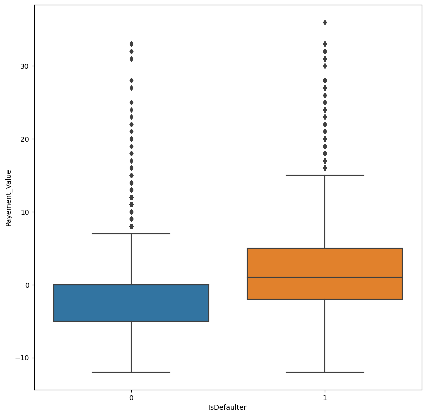

```python
plt.figure(figsize=(10,10))
sns.boxplot(data = df_fr, x = 'IsDefaulter', y = 'Payement_Value' )
```

```python
df_fr['Dues'] = (df_fr['BILL_AMT_APR']+df_fr['BILL_AMT_MAY']+df_fr['BILL_AMT_JUN']+df_fr['BILL_AMT_JUL']+df_fr['BILL_AMT_SEPT'])-(df_fr['PAY_AMT_APR']+df_fr['PAY_AMT_MAY']+df_fr['PAY_AMT_JUN']+df_fr['PAY_AMT_JUL']+df_fr['PAY_AMT_AUG']+df_fr['PAY_AMT_SEPT'])
```

```python
df_fr.groupby('IsDefaulter')['Dues'].mean()
```

```
IsDefaulter
0    189843.942709
1    191740.075757
Name: Dues, dtype: float64
```

```python
df_fr['EDUCATION'].unique()
```

```
array([2, 1, 3, 4])
```

```python
df_fr['EDUCATION']=np.where(df_fr['EDUCATION'] == 6, 4, df_fr['EDUCATION'])
df_fr['EDUCATION']=np.where(df_fr['EDUCATION'] == 0, 4, df_fr['EDUCATION'])
```

```python
df_fr['MARRIAGE'].unique()
```

```
array([2, 1, 3])
```

```python
df_fr['MARRIAGE']=np.where(df_fr['MARRIAGE'] == 0, 3, df_fr['MARRIAGE'])
```

```python
df_fr.replace({'SEX': {1 : 'MALE', 2 : 'FEMALE'}, 'EDUCATION' : {1 : 'graduate school', 2 : 'university', 3 : 'high school', 4 : 'others'}, 'MARRIAGE' : {1 : 'married', 2 : 'single', 3 : 'others'}}, inplace = True)
```

```python
df_fr.head()
```

|  | ID | LIMIT_BAL | SEX | EDUCATION | MARRIAGE | AGE | PAY_SEPT | PAY_AUG | PAY_JUL | PAY_JUN | ... | PAY_AMT_SEPT | PAY_AMT_AUG | PAY_AMT_JUL | PAY_AMT_JUN | PAY_AMT_MAY | PAY_AMT_APR | default_payment_next_month | IsDefaulter | Payement_Value | Dues |
| --- | --- | --- | --- | --- | --- | --- | --- | --- | --- | --- | --- | --- | --- | --- | --- | --- | --- | --- | --- | --- | --- |
| 0 | 25150 | 360000 | FEMALE | university | single | 25 | -1 | -1 | -1 | -1 | ... | 12590 | 3479 | 3446 | 8870 | 2020 | 27043 | 0 | 0 | -6 | -18692 |
| 1 | 13470 | 240000 | FEMALE | graduate school | single | 46 | 2 | 2 | -2 | -1 | ... | 0 | 0 | 2240 | 0 | 2267 | 3074 | 0 | 0 | 0 | -937 |
| 2 | 3092 | 320000 | FEMALE | university | married | 41 | 0 | 0 | 0 | 0 | ... | 5000 | 2000 | 2000 | 3000 | 3000 | 1500 | 0 | 0 | 0 | 178447 |
| 3 | 13973 | 50000 | FEMALE | university | single | 24 | -1 | -1 | -2 | -2 | ... | 0 | 0 | 0 | 0 | 0 | 0 | 1 | 1 | -10 | 2675 |
| 4 | 10567 | 80000 | MALE | high school | married | 52 | -1 | 0 | 0 | 0 | ... | 1500 | 1500 | 1500 | 1028 | 876 | 1449 | 0 | 0 | -1 | 110672 |

5 rows × 28 columns

# One Hot Encoding

```python
df_fr = pd.get_dummies(df_fr,columns=['EDUCATION','MARRIAGE'])
```

```python
df_fr.head()
```

|  | ID | LIMIT_BAL | SEX | AGE | PAY_SEPT | PAY_AUG | PAY_JUL | PAY_JUN | PAY_MAY | PAY_APR | ... | IsDefaulter | Payement_Value | Dues | EDUCATION_graduate school | EDUCATION_high school | EDUCATION_others | EDUCATION_university | MARRIAGE_married | MARRIAGE_others | MARRIAGE_single |
| --- | --- | --- | --- | --- | --- | --- | --- | --- | --- | --- | --- | --- | --- | --- | --- | --- | --- | --- | --- | --- | --- |
| 0 | 25150 | 360000 | FEMALE | 25 | -1 | -1 | -1 | -1 | -1 | -1 | ... | 0 | -6 | -18692 | 0 | 0 | 0 | 1 | 0 | 0 | 1 |
| 1 | 13470 | 240000 | FEMALE | 46 | 2 | 2 | -2 | -1 | 0 | -1 | ... | 0 | 0 | -937 | 1 | 0 | 0 | 0 | 0 | 0 | 1 |
| 2 | 3092 | 320000 | FEMALE | 41 | 0 | 0 | 0 | 0 | 0 | 0 | ... | 0 | 0 | 178447 | 0 | 0 | 0 | 1 | 1 | 0 | 0 |
| 3 | 13973 | 50000 | FEMALE | 24 | -1 | -1 | -2 | -2 | -2 | -2 | ... | 1 | -10 | 2675 | 0 | 0 | 0 | 1 | 0 | 0 | 1 |
| 4 | 10567 | 80000 | MALE | 52 | -1 | 0 | 0 | 0 | 0 | 0 | ... | 0 | -1 | 110672 | 0 | 1 | 0 | 0 | 1 | 0 | 0 |

5 rows × 33 columns

```python
df_fr.drop(['EDUCATION_others','MARRIAGE_others'],axis = 1, inplace = True)
```

```python
df_fr.head()
```

|  | ID | LIMIT_BAL | SEX | AGE | PAY_SEPT | PAY_AUG | PAY_JUL | PAY_JUN | PAY_MAY | PAY_APR | ... | PAY_AMT_APR | default_payment_next_month | IsDefaulter | Payement_Value | Dues | EDUCATION_graduate school | EDUCATION_high school | EDUCATION_university | MARRIAGE_married | MARRIAGE_single |
| --- | --- | --- | --- | --- | --- | --- | --- | --- | --- | --- | --- | --- | --- | --- | --- | --- | --- | --- | --- | --- | --- |
| 0 | 25150 | 360000 | FEMALE | 25 | -1 | -1 | -1 | -1 | -1 | -1 | ... | 27043 | 0 | 0 | -6 | -18692 | 0 | 0 | 1 | 0 | 1 |
| 1 | 13470 | 240000 | FEMALE | 46 | 2 | 2 | -2 | -1 | 0 | -1 | ... | 3074 | 0 | 0 | 0 | -937 | 1 | 0 | 0 | 0 | 1 |
| 2 | 3092 | 320000 | FEMALE | 41 | 0 | 0 | 0 | 0 | 0 | 0 | ... | 1500 | 0 | 0 | 0 | 178447 | 0 | 0 | 1 | 1 | 0 |
| 3 | 13973 | 50000 | FEMALE | 24 | -1 | -1 | -2 | -2 | -2 | -2 | ... | 0 | 1 | 1 | -10 | 2675 | 0 | 0 | 1 | 0 | 1 |
| 4 | 10567 | 80000 | MALE | 52 | -1 | 0 | 0 | 0 | 0 | 0 | ... | 1449 | 0 | 0 | -1 | 110672 | 0 | 1 | 0 | 1 | 0 |

5 rows × 31 columns

```python
df_fr = pd.get_dummies(df_fr, columns = ['PAY_SEPT',	'PAY_AUG',	'PAY_JUL',	'PAY_JUN',	'PAY_MAY',	'PAY_APR'], drop_first = True )
```

```python
df_fr.head()
```

|  | ID | LIMIT_BAL | SEX | AGE | BILL_AMT_SEPT | BILL_AMT_AUG | BILL_AMT_JUL | BILL_AMT_JUN | BILL_AMT_MAY | BILL_AMT_APR | ... | PAY_APR_-1 | PAY_APR_0 | PAY_APR_1 | PAY_APR_2 | PAY_APR_3 | PAY_APR_4 | PAY_APR_5 | PAY_APR_6 | PAY_APR_7 | PAY_APR_8 |
| --- | --- | --- | --- | --- | --- | --- | --- | --- | --- | --- | --- | --- | --- | --- | --- | --- | --- | --- | --- | --- | --- |
| 0 | 25150 | 360000 | FEMALE | 25 | 20952 | 12590 | 3479 | 3435 | 8870 | 2020 | ... | 1 | 0 | 0 | 0 | 0 | 0 | 0 | 0 | 0 | 0 |
| 1 | 13470 | 240000 | FEMALE | 46 | 456 | 0 | 0 | 2240 | 1681 | 2267 | ... | 1 | 0 | 0 | 0 | 0 | 0 | 0 | 0 | 0 | 0 |
| 2 | 3092 | 320000 | FEMALE | 41 | 49846 | 53811 | 38717 | 35409 | 35036 | 35939 | ... | 0 | 1 | 0 | 0 | 0 | 0 | 0 | 0 | 0 | 0 |
| 3 | 13973 | 50000 | FEMALE | 24 | 2675 | 0 | 0 | 0 | 0 | 0 | ... | 0 | 0 | 0 | 0 | 0 | 0 | 0 | 0 | 0 | 0 |
| 4 | 10567 | 80000 | MALE | 52 | 35861 | 18521 | 19385 | 20561 | 21261 | 21457 | ... | 0 | 1 | 0 | 0 | 0 | 0 | 0 | 0 | 0 | 0 |

5 rows × 85 columns

```python
df_fr
```

|  | ID | LIMIT_BAL | SEX | AGE | BILL_AMT_SEPT | BILL_AMT_AUG | BILL_AMT_JUL | BILL_AMT_JUN | BILL_AMT_MAY | BILL_AMT_APR | ... | PAY_APR_-1 | PAY_APR_0 | PAY_APR_1 | PAY_APR_2 | PAY_APR_3 | PAY_APR_4 | PAY_APR_5 | PAY_APR_6 | PAY_APR_7 | PAY_APR_8 |
| --- | --- | --- | --- | --- | --- | --- | --- | --- | --- | --- | --- | --- | --- | --- | --- | --- | --- | --- | --- | --- | --- |
| 0 | 25150 | 360000 | FEMALE | 25 | 20952 | 12590 | 3479 | 3435 | 8870 | 2020 | ... | 1 | 0 | 0 | 0 | 0 | 0 | 0 | 0 | 0 | 0 |
| 1 | 13470 | 240000 | FEMALE | 46 | 456 | 0 | 0 | 2240 | 1681 | 2267 | ... | 1 | 0 | 0 | 0 | 0 | 0 | 0 | 0 | 0 | 0 |
| 2 | 3092 | 320000 | FEMALE | 41 | 49846 | 53811 | 38717 | 35409 | 35036 | 35939 | ... | 0 | 1 | 0 | 0 | 0 | 0 | 0 | 0 | 0 | 0 |
| 3 | 13973 | 50000 | FEMALE | 24 | 2675 | 0 | 0 | 0 | 0 | 0 | ... | 0 | 0 | 0 | 0 | 0 | 0 | 0 | 0 | 0 | 0 |
| 4 | 10567 | 80000 | MALE | 52 | 35861 | 18521 | 19385 | 20561 | 21261 | 21457 | ... | 0 | 1 | 0 | 0 | 0 | 0 | 0 | 0 | 0 | 0 |
| ... | ... | ... | ... | ... | ... | ... | ... | ... | ... | ... | ... | ... | ... | ... | ... | ... | ... | ... | ... | ... | ... |
| 32705 | 22250 | 300000 | FEMALE | 38 | 12465 | 10457 | 3510 | 2831 | 7937 | 22254 | ... | 1 | 0 | 0 | 0 | 0 | 0 | 0 | 0 | 0 | 0 |
| 32706 | 23119 | 74801 | MALE | 37 | 7219 | 5625 | 17264 | 16613 | 16930 | 16739 | ... | 0 | 1 | 0 | 0 | 0 | 0 | 0 | 0 | 0 | 0 |
| 32707 | 26758 | 20000 | MALE | 34 | 5732 | 7201 | 8748 | 10316 | 11366 | 12326 | ... | 0 | 1 | 0 | 0 | 0 | 0 | 0 | 0 | 0 | 0 |
| 32708 | 18330 | 20000 | MALE | 25 | 12399 | 14778 | 14353 | 15507 | 15494 | 15869 | ... | 0 | 1 | 0 | 0 | 0 | 0 | 0 | 0 | 0 | 0 |
| 32709 | 19033 | 20000 | FEMALE | 36 | 6036 | 6415 | 7433 | 8288 | 8528 | 8704 | ... | 0 | 1 | 0 | 0 | 0 | 0 | 0 | 0 | 0 | 0 |

32710 rows × 85 columns

```python
# LABEL ENCODING FOR SEX
encoders_nums = {
                 "SEX":{"FEMALE": 0, "MALE": 1}
}
df_fr = df_fr.replace(encoders_nums)
```

```python
df_fr.head()
```

|  | ID | LIMIT_BAL | SEX | AGE | BILL_AMT_SEPT | BILL_AMT_AUG | BILL_AMT_JUL | BILL_AMT_JUN | BILL_AMT_MAY | BILL_AMT_APR | ... | PAY_APR_-1 | PAY_APR_0 | PAY_APR_1 | PAY_APR_2 | PAY_APR_3 | PAY_APR_4 | PAY_APR_5 | PAY_APR_6 | PAY_APR_7 | PAY_APR_8 |
| --- | --- | --- | --- | --- | --- | --- | --- | --- | --- | --- | --- | --- | --- | --- | --- | --- | --- | --- | --- | --- | --- |
| 0 | 25150 | 360000 | 0 | 25 | 20952 | 12590 | 3479 | 3435 | 8870 | 2020 | ... | 1 | 0 | 0 | 0 | 0 | 0 | 0 | 0 | 0 | 0 |
| 1 | 13470 | 240000 | 0 | 46 | 456 | 0 | 0 | 2240 | 1681 | 2267 | ... | 1 | 0 | 0 | 0 | 0 | 0 | 0 | 0 | 0 | 0 |
| 2 | 3092 | 320000 | 0 | 41 | 49846 | 53811 | 38717 | 35409 | 35036 | 35939 | ... | 0 | 1 | 0 | 0 | 0 | 0 | 0 | 0 | 0 | 0 |
| 3 | 13973 | 50000 | 0 | 24 | 2675 | 0 | 0 | 0 | 0 | 0 | ... | 0 | 0 | 0 | 0 | 0 | 0 | 0 | 0 | 0 | 0 |
| 4 | 10567 | 80000 | 1 | 52 | 35861 | 18521 | 19385 | 20561 | 21261 | 21457 | ... | 0 | 1 | 0 | 0 | 0 | 0 | 0 | 0 | 0 | 0 |

5 rows × 85 columns

```python
df_fr.drop('ID',axis = 1, inplace = True)
```

```python
df_fr.to_csv('Final_df.csv')
```

```python
df_fr = pd.read_csv('./Final_df.csv')
```

```python
df_fr.head()
```

|  | Unnamed: 0 | LIMIT_BAL | SEX | AGE | BILL_AMT_SEPT | BILL_AMT_AUG | BILL_AMT_JUL | BILL_AMT_JUN | BILL_AMT_MAY | BILL_AMT_APR | ... | PAY_APR_-1 | PAY_APR_0 | PAY_APR_1 | PAY_APR_2 | PAY_APR_3 | PAY_APR_4 | PAY_APR_5 | PAY_APR_6 | PAY_APR_7 | PAY_APR_8 |
| --- | --- | --- | --- | --- | --- | --- | --- | --- | --- | --- | --- | --- | --- | --- | --- | --- | --- | --- | --- | --- | --- |
| 0 | 0 | 360000 | 0 | 25 | 20952 | 12590 | 3479 | 3435 | 8870 | 2020 | ... | 1 | 0 | 0 | 0 | 0 | 0 | 0 | 0 | 0 | 0 |
| 1 | 1 | 240000 | 0 | 46 | 456 | 0 | 0 | 2240 | 1681 | 2267 | ... | 1 | 0 | 0 | 0 | 0 | 0 | 0 | 0 | 0 | 0 |
| 2 | 2 | 320000 | 0 | 41 | 49846 | 53811 | 38717 | 35409 | 35036 | 35939 | ... | 0 | 1 | 0 | 0 | 0 | 0 | 0 | 0 | 0 | 0 |
| 3 | 3 | 50000 | 0 | 24 | 2675 | 0 | 0 | 0 | 0 | 0 | ... | 0 | 0 | 0 | 0 | 0 | 0 | 0 | 0 | 0 | 0 |
| 4 | 4 | 80000 | 1 | 52 | 35861 | 18521 | 19385 | 20561 | 21261 | 21457 | ... | 0 | 1 | 0 | 0 | 0 | 0 | 0 | 0 | 0 | 0 |

5 rows × 85 columns

```python
df_fr.drop(['Unnamed: 0'],axis = 1, inplace = True) # hapus kolom yang tidak di pakai saat inin membuat model
```